# Lab 1

Emil Luusua

17 September 2019

## Question 1

Two runs of the hill-climbing algorithm can return non-equivalent BN structures. This can easily be shown by modifying the iss score parameter, which controls the imaginary sample size of the BDeu score.

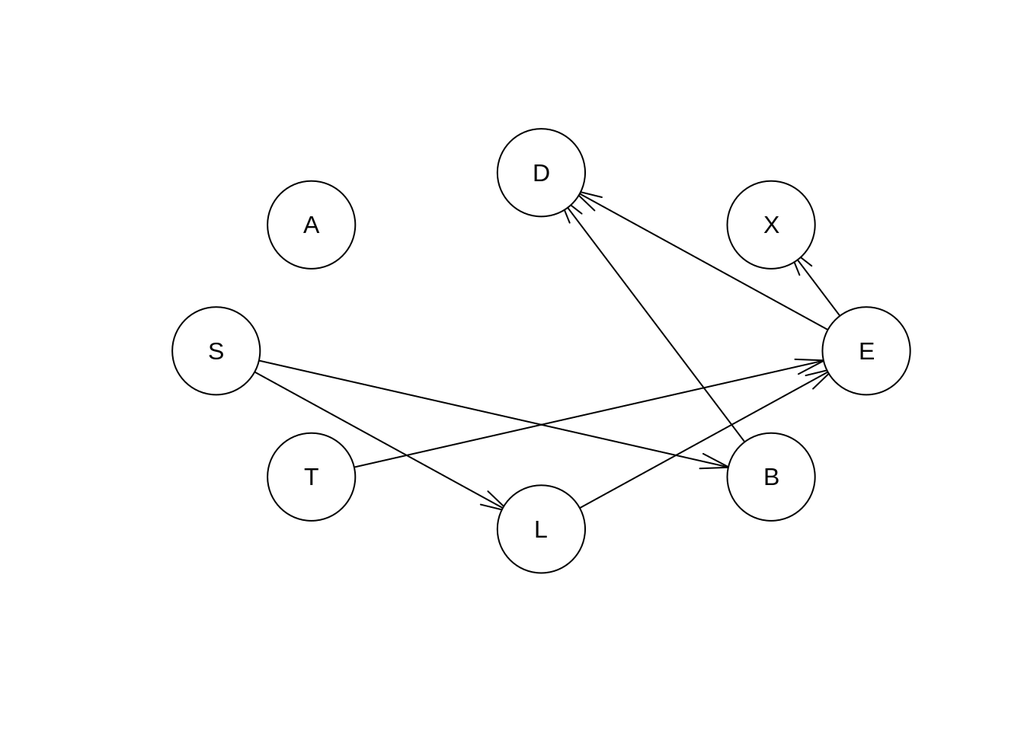

```r
dag <- hc(asia, score = 'bde', iss = 1)
plot(dag)
```

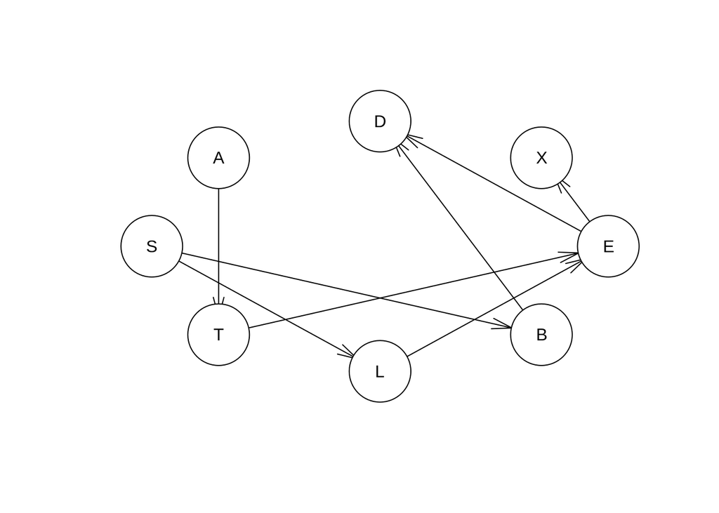

```r
plot(hc(asia, score = 'bde', iss = 2))
```

Note the additional arc between from ‘A’ to ‘T’ in the second plot. Differences in the resulting graph such as this can occur when using different scorings since it will influence how different aspects are weighted, in the case of iss the weight given to the prior is altered.

## Question 2

We start by splitting the data into train and test sets. Also extract labels S from the test set.

```r
set.seed(1)
sample_size <- floor(0.8 * nrow(asia))
train_indices <- sample(seq_len(nrow(asia)), size = sample_size)

asia_train <- asia[train_indices, ]
asia_test <- asia[-train_indices, ]
labels <- asia_test['S']
asia_test$S <- NULL
```

We use the structure learnt with by Hill Climbing in question 1 and learn the parameters of the model with Maximum Likelihood parameter estimation since we are not missing any data.

```r
fit <- bn.fit(dag, asia_train)
```

We perform classification of the test set using exact inference in gRain and display the results in a confusion matrix using caret.

```r
net <- compile(as.grain(fit))
data <- list()

for (i in seq_len(nrow(asia_test))) {
  evidence <- list()

  for (col in colnames(asia_test)) {
    evidence <- append(evidence, as.character(asia_test[i, col]))
  }

  posterior <- querygrain(setFinding(net, nodes=colnames(asia_test), states=evidence))$S

  if (posterior['yes'] > posterior['no']) {
    # Classify as positive
    data <- append(data, 'yes')

  } else {
    # Classify as negative
    data <- append(data, 'no')
  }
}
confusionMatrix(factor(unlist(data)), factor(unlist(labels)))
```

```
## Confusion Matrix and Statistics
##
##           Reference
## Prediction  no yes
##        no  334 131
##        yes 136 399
##
##                Accuracy : 0.733
##                  95% CI : (0.7044, 0.7602)
##     No Information Rate : 0.53
##     P-Value [Acc > NIR] : <2e-16
##
##                   Kappa : 0.4637
##
##  Mcnemar's Test P-Value : 0.8066
##
##             Sensitivity : 0.7106
##             Specificity : 0.7528
##          Pos Pred Value : 0.7183
##          Neg Pred Value : 0.7458
##              Prevalence : 0.4700
##          Detection Rate : 0.3340
##    Detection Prevalence : 0.4650
##       Balanced Accuracy : 0.7317
##
##        'Positive' Class : no
##
```

We then compare the results when using the true structure, with parameters still learned from the training data. This is shown to be exactly the same.

```r
true_dag <- model2network("[A][S][T|A][L|S][B|S][D|B:E][E|T:L][X|E]")
true_fit <- bn.fit(true_dag, asia_train)

true_net <- compile(as.grain(true_fit))
data <- list()

for (i in seq_len(nrow(asia_test))) {
  evidence <- list()

  for (col in colnames(asia_test)) {
    evidence <- append(evidence, as.character(asia_test[i, col]))
  }

  posterior <- querygrain(setFinding(true_net, nodes=colnames(asia_test), states=evidence))$S

  if (posterior['yes'] > posterior['no']) {
    # Classify as positive
    data <- append(data, 'yes')

  } else {
    # Classify as negative
    data <- append(data, 'no')
  }
}
confusionMatrix(factor(unlist(data)), factor(unlist(labels)))
```

```
## Confusion Matrix and Statistics
##
##           Reference
## Prediction  no yes
##        no  334 131
##        yes 136 399
##
##                Accuracy : 0.733
##                  95% CI : (0.7044, 0.7602)
##     No Information Rate : 0.53
##     P-Value [Acc > NIR] : <2e-16
##
##                   Kappa : 0.4637
##
##  Mcnemar's Test P-Value : 0.8066
##
##             Sensitivity : 0.7106
##             Specificity : 0.7528
##          Pos Pred Value : 0.7183
##          Neg Pred Value : 0.7458
##              Prevalence : 0.4700
##          Detection Rate : 0.3340
##    Detection Prevalence : 0.4650
##       Balanced Accuracy : 0.7317
##
##        'Positive' Class : no
##
```

## Question 3

What is the Markov blanket of S?

```r
mb(dag, 'S')
```

```
## [1] "L" "B"
```

We thus perform the same procedure for classification as previously, only the evidence is altered such that it contains observations for L and B. Once again the results are identical.

```r
observations <- c('L', 'B')
data <- list()

for (i in seq_len(nrow(asia_test))) {
  evidence <- list()

  for (col in observations) {
    evidence <- append(evidence, as.character(asia_test[i, col]))
  }

  posterior <- querygrain(setFinding(net, nodes=observations, states=evidence))$S

  if (posterior['yes'] > posterior['no']) {
    # Classify as positive
    data <- append(data, 'yes')

  } else {
    # Classify as negative
    data <- append(data, 'no')
  }
}
confusionMatrix(factor(unlist(data)), factor(unlist(labels)))
```

```
## Confusion Matrix and Statistics
##
##           Reference
## Prediction  no yes
##        no  334 131
##        yes 136 399
##
##                Accuracy : 0.733
##                  95% CI : (0.7044, 0.7602)
##     No Information Rate : 0.53
##     P-Value [Acc > NIR] : <2e-16
##
##                   Kappa : 0.4637
##
##  Mcnemar's Test P-Value : 0.8066
##
##             Sensitivity : 0.7106
##             Specificity : 0.7528
##          Pos Pred Value : 0.7183
##          Neg Pred Value : 0.7458
##              Prevalence : 0.4700
##          Detection Rate : 0.3340
##    Detection Prevalence : 0.4650
##       Balanced Accuracy : 0.7317
##
##        'Positive' Class : no
##
```

A Naïve Bayes classifier can be represented by a Bayesian network where the prediction variable is the sole parent of all other variables. This will result in the graph representing the same conditional independence as is assumed for a Naïve Bayes model.

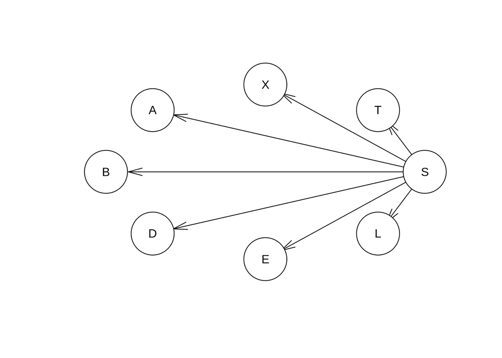

```r
naive_dag <- model2network("[S][A|S][T|S][L|S][B|S][D|S][E|S][X|S]")
naive_fit <- bn.fit(naive_dag, asia_train)
plot(naive_dag)
```

```r
naive_net <- compile(as.grain(fit))
data <- list()

for (i in seq_len(nrow(asia_test))) {
  evidence <- list()

  for (col in colnames(asia_test)) {
    evidence <- append(evidence, as.character(asia_test[i, col]))
  }

  posterior <- querygrain(setFinding(naive_net, nodes=colnames(asia_test), states=evidence))$S

  if (posterior['yes'] > posterior['no']) {
    # Classify as positive
    data <- append(data, 'yes')

  } else {
    # Classify as negative
    data <- append(data, 'no')
  }
}
confusionMatrix(factor(unlist(data)), factor(unlist(labels)))
```

```
## Confusion Matrix and Statistics
##
##           Reference
## Prediction  no yes
##        no  334 131
##        yes 136 399
##
##                Accuracy : 0.733
##                  95% CI : (0.7044, 0.7602)
##     No Information Rate : 0.53
##     P-Value [Acc > NIR] : <2e-16
##
##                   Kappa : 0.4637
##
##  Mcnemar's Test P-Value : 0.8066
##
##             Sensitivity : 0.7106
##             Specificity : 0.7528
##          Pos Pred Value : 0.7183
##          Neg Pred Value : 0.7458
##              Prevalence : 0.4700
##          Detection Rate : 0.3340
##    Detection Prevalence : 0.4650
##       Balanced Accuracy : 0.7317
##
##        'Positive' Class : no
##
```

## Question 5

The first three cases are quite clear, since S will have the same Markov blanket in all these graphs (L and B). As these variables are observed in each case, the S node will be independent from all other nodes. As such observing the other nodes or modeling the independencies among them will not make a difference to the classification of S.